# Project:Exploration of NOAA Storm Database

Reshu

1 June 2017

## Synopsis

The basic goal of this assignment is to explore the NOAA Storm Database and predict which weather events have the most impact on population health (considering Falaties and injuries) and Economy (considering Property and Crop damage). For analysis, we read file and store the data in a dataframe.We reformat data to make it suitable for analysis. For Problem 1,We first group by EVTYPE and sum column “FATALITIES” and “INJURIES” to store Total impact for a particular EVTYPE in a new column Weather_impact and then we plot between fields “Weather_impact” and “EVTYPE” to find which type of events are most harmful to health. For Problem 2, We first find absolute values of PROPDMG and CROPDMG by multiplying with respective multipliers .We then group by EVTYPE and sum column “PROPDMG” and “CROPDMG” to store sum for a particular EVTYPE in a new column “Economy_impact” and then plot between fields “Economy_impact” and “EVTYPE” to find which type of events have most economic consequences.

## Data Processing

### Loading data

```r
dataFile<-"~/Documents/Reproducible_search_Proj2/repdata_data_StormData.csv"
data1<-read.csv(dataFile,header=TRUE,sep=",",stringsAsFactors = FALSE,na.strings=" ")
```

## Data Processing

Cleaning and formatting the data for further analysis

```r
##Finding out unique exponential values for Property damage exponent
print(unique(data1$PROPDMGEXP))
```

```
##  [1] "K" "M" ""  "B" "m" "+" "0" "5" "6" "?" "4" "2" "3" "h" "7" "H" "-"
## [18] "1" "8"
```

```r
##Finding out unique exponential values for Crop damage exponent
print(unique(data1$CROPDMGEXP))
```

```
## [1] ""  "M" "K" "m" "B" "?" "0" "k" "2"
```

```r
## converting lower case characters to upper for Property damage exponent
data1$PROPDMGEXP<-factor(toupper(data1$PROPDMGEXP))
data1$CROPDMGEXP<-factor(toupper(data1$CROPDMGEXP))
```

## Weather events that cause the most impact on human health

```r
Weather_impact<-aggregate(data1$FATALITIES+data1$INJURIES,by=list(data1$EVTYPE),sum,na.rm=TRUE)
colnames(Weather_impact)<-c("Event","Impact")
a<-arrange(Weather_impact,desc(Impact))[1:10,]
a
```

```
##                Event Impact
## 1            TORNADO  96979
## 2     EXCESSIVE HEAT   8428
## 3          TSTM WIND   7461
## 4              FLOOD   7259
## 5          LIGHTNING   6046
## 6               HEAT   3037
## 7        FLASH FLOOD   2755
## 8          ICE STORM   2064
## 9  THUNDERSTORM WIND   1621
## 10      WINTER STORM   1527
```

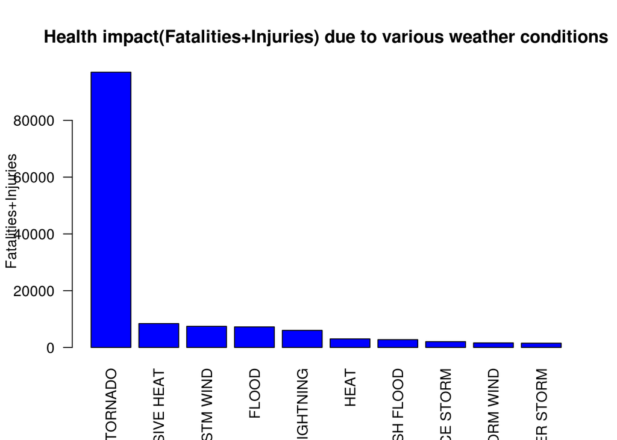

```r
##ggplot(aes(x=Weather_impact$Group.1,y=Weather_impact$x),data=data1)
barplot(height=a$Impact,names.arg = a$Event,main="Health impact(Fatalities+Injuries) due to various weather conditions",beside=TRUE,col=("blue"),ylab="Fatalities+Injuries",las=2)
```

## Weather events that have the most economical consequences(Property+Crop damage)

```r
##Finding multiplier value for PROPDMG corresponding to PROPDMGEXP
data1$PROPDMGE<-0
data1$PROPDMGE<-0
data1[grep("K",data1$PROPDMGEXP),"PROPDMGE"]<-1000
data1[grep("B",data1$PROPDMGEXP),"PROPDMGE"]<-1000000000
##data1[grep("1",data1$PROPDMGEXP),"PROPDMGE"]<-10
data1[grep("2",data1$PROPDMGEXP),"PROPDMGE"]<-100
data1[grep("3",data1$PROPDMGEXP),"PROPDMGE"]<-1000
data1[grep("4",data1$PROPDMGEXP),"PROPDMGE"]<-10000
data1[grep("5",data1$PROPDMGEXP),"PROPDMGE"]<-100000
data1[grep("6",data1$PROPDMGEXP),"PROPDMGE"]<-1000000
data1[grep("7",data1$PROPDMGEXP),"PROPDMGE"]<-10000000
data1[grep("8",data1$PROPDMGEXP),"PROPDMGE"]<-100000000
data1[grep("H",data1$PROPDMGEXP),"PROPDMGE"]<-100
data1[grep("M",data1$PROPDMGEXP),"PROPDMGE"]<-1000000
##data1[grep(("+|-|?|0"),data1$PROPDMGEXP),"PROPDMGE"]<-0
##Finding multiplier value for CROPDMG corresponding to CROPDMGEXP
data1[grep("K",data1$CROPDMGEXP),"CROPDMGE"]<-1000
data1[grep("K",data1$CROPDMGEXP),"CROPDMGE"]<-1000
data1[grep("M",data1$CROPDMGEXP),"CROPDMGE"]<-1000000
data1[grep("B",data1$CROPDMGEXP),"CROPDMGE"]<-1000000000
##data1[grep(("+|-|?|0"),data1$CROPDMGEXP),"CROPDMGE"]<-0
##Finding total economical damage in US (Property+Crop)
data1$TOTALPROPDMG<-0
data1$TOTALCROPDMG<-0
data1$TOTALDMG<-0
data1$TOTALPROPDMG<-data1$PROPDMG*data1$PROPDMGE
data1$TOTALCROPDMG<-data1$CROPDMG*data1$CROPDMGE
data1$TOTALDMG<-data1$TOTALPROPDMG+data1$TOTALCROPDMG
##Plotting Total damage vs Event type
Economy_impact<-aggregate(data1$TOTALDMG,by=list(data1$EVTYPE),sum,na.rm=TRUE)
colnames(Economy_impact)<-c("Event","EconomyImpact")
b<-arrange(Economy_impact,desc(EconomyImpact))[1:10,]
b
```

```
##                Event EconomyImpact
## 1              FLOOD  138498457500
## 2  HURRICANE/TYPHOON   29348167800
## 3            TORNADO   16581724800
## 4            DROUGHT   14206287000
## 5          HURRICANE   12458268000
## 6               HAIL   11020738140
## 7        RIVER FLOOD   10109094000
## 8        FLASH FLOOD    8749813180
## 9          ICE STORM    5925150800
## 10  STORM SURGE/TIDE    4641493000
```

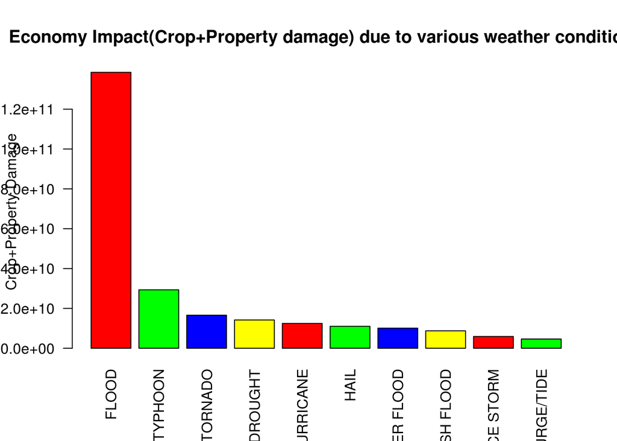

```r
##ggplot(aes(x=Weather_impact$Group.1,y=Weather_impact$x),data=data1)
barplot(height=b$EconomyImpact,names.arg =b$Event,main="Economy Impact(Crop+Property damage) due to various weather conditions",col=c("red","green","blue","yellow"),ylab="Crop+Property Damage",las=2)
```

## Results

According to the analysis above we deduce that 1.Tornado weather event is most harmful for population health in US 2.Flood is the weather event that causes the most economical damage (considering Property and Crop damage)in US